# Pandas

```python
import pandas as pd
import seaborn as sns
import numpy as np
np.warnings.filterwarnings('ignore')
sns.set()

df = pd.read_csv('/Users/drewmcknight1/Desktop/MISY630/Fall 2020 Course Files/Assignments/responses.csv')
df.head()
```

|  | Music | Slow songs or fast songs | Dance | Folk | Country | Classical music | Musical | Pop | Rock | Metal or Hardrock | ... | Age | Height | Weight | Number of siblings | Gender | Left - right handed | Education | Only child | Village - town | House - block of flats |
| --- | --- | --- | --- | --- | --- | --- | --- | --- | --- | --- | --- | --- | --- | --- | --- | --- | --- | --- | --- | --- | --- |
| 0 | 5.0 | 3.0 | 2.0 | 1.0 | 2.0 | 2.0 | 1.0 | 5.0 | 5.0 | 1.0 | ... | 20.0 | 163.0 | 48.0 | 1.0 | female | right handed | college/bachelor degree | no | village | block of flats |
| 1 | 4.0 | 4.0 | 2.0 | 1.0 | 1.0 | 1.0 | 2.0 | 3.0 | 5.0 | 4.0 | ... | 19.0 | 163.0 | 58.0 | 2.0 | female | right handed | college/bachelor degree | no | city | block of flats |
| 2 | 5.0 | 5.0 | 2.0 | 2.0 | 3.0 | 4.0 | 5.0 | 3.0 | 5.0 | 3.0 | ... | 20.0 | 176.0 | 67.0 | 2.0 | female | right handed | secondary school | no | city | block of flats |
| 3 | 5.0 | 3.0 | 2.0 | 1.0 | 1.0 | 1.0 | 1.0 | 2.0 | 2.0 | 1.0 | ... | 22.0 | 172.0 | 59.0 | 1.0 | female | right handed | college/bachelor degree | yes | city | house/bungalow |
| 4 | 5.0 | 3.0 | 4.0 | 3.0 | 2.0 | 4.0 | 3.0 | 5.0 | 3.0 | 1.0 | ... | 20.0 | 170.0 | 59.0 | 1.0 | female | right handed | secondary school | no | village | house/bungalow |

5 rows × 150 columns

```python
df2 = df[['Music', 'Slow songs or fast songs', 'Dance', 'Folk', 'Country', 'Classical music', 'Musical', 'Pop', 'Rock', 'Metal or Hardrock']].copy()
df2.rename(columns={'Metal or Hardrock': 'HardRock'}, inplace=True)
df2.head()
```

|  | Music | Slow songs or fast songs | Dance | Folk | Country | Classical music | Musical | Pop | Rock | HardRock |
| --- | --- | --- | --- | --- | --- | --- | --- | --- | --- | --- |
| 0 | 5.0 | 3.0 | 2.0 | 1.0 | 2.0 | 2.0 | 1.0 | 5.0 | 5.0 | 1.0 |
| 1 | 4.0 | 4.0 | 2.0 | 1.0 | 1.0 | 1.0 | 2.0 | 3.0 | 5.0 | 4.0 |
| 2 | 5.0 | 5.0 | 2.0 | 2.0 | 3.0 | 4.0 | 5.0 | 3.0 | 5.0 | 3.0 |
| 3 | 5.0 | 3.0 | 2.0 | 1.0 | 1.0 | 1.0 | 1.0 | 2.0 | 2.0 | 1.0 |
| 4 | 5.0 | 3.0 | 4.0 | 3.0 | 2.0 | 4.0 | 3.0 | 5.0 | 3.0 | 1.0 |

```python
df2.loc[df.Gender == 'male', 'GenderCode'] = 1
df2.loc[df.Gender == 'female', 'GenderCode'] = 0
df2.head(8)
```

|  | Music | Slow songs or fast songs | Dance | Folk | Country | Classical music | Musical | Pop | Rock | HardRock | GenderCode |
| --- | --- | --- | --- | --- | --- | --- | --- | --- | --- | --- | --- |
| 0 | 5.0 | 3.0 | 2.0 | 1.0 | 2.0 | 2.0 | 1.0 | 5.0 | 5.0 | 1.0 | 0.0 |
| 1 | 4.0 | 4.0 | 2.0 | 1.0 | 1.0 | 1.0 | 2.0 | 3.0 | 5.0 | 4.0 | 0.0 |
| 2 | 5.0 | 5.0 | 2.0 | 2.0 | 3.0 | 4.0 | 5.0 | 3.0 | 5.0 | 3.0 | 0.0 |
| 3 | 5.0 | 3.0 | 2.0 | 1.0 | 1.0 | 1.0 | 1.0 | 2.0 | 2.0 | 1.0 | 0.0 |
| 4 | 5.0 | 3.0 | 4.0 | 3.0 | 2.0 | 4.0 | 3.0 | 5.0 | 3.0 | 1.0 | 0.0 |
| 5 | 5.0 | 3.0 | 2.0 | 3.0 | 2.0 | 3.0 | 3.0 | 2.0 | 5.0 | 5.0 | 1.0 |
| 6 | 5.0 | 5.0 | 5.0 | 3.0 | 1.0 | 2.0 | 2.0 | 5.0 | 3.0 | 1.0 | 0.0 |
| 7 | 5.0 | 3.0 | 3.0 | 2.0 | 1.0 | 2.0 | 2.0 | 4.0 | 5.0 | 1.0 | 1.0 |

```python
df2['HardRock'].groupby(df2['GenderCode']).mean()
```

```
GenderCode
0.0    2.160473
1.0    2.639024
Name: HardRock, dtype: float64
```

# Visualizations

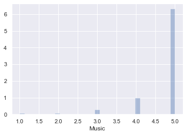

```python
sns.distplot(df2.Music)
```

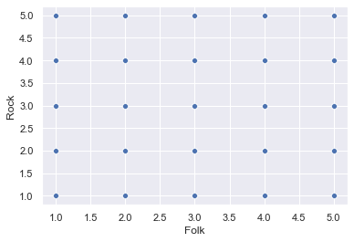

```python
sns.scatterplot(x="Folk", y="Rock", data=df2)
```

This indicates that there is no relationship between folk and rock preferences. They are independent of each other.

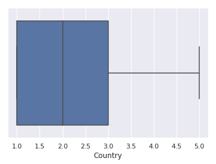

```python
sns.boxplot(df2.Country)
```

- For country, the middle 50% is evenly distributed from the median of 2
- the 1st quartile (25%) has a value of 1
- the 3rd quartile (75%) a value of 3
- max value of 5

# Descriptive Stats

```python
df3 = df[['Gender', 'Height', 'Weight', 'Age']].copy()
df3.isnull().sum()
```

```
Gender     6
Height    20
Weight    20
Age        7
dtype: int64
```

The above shows the sum of null values for each category.

```python
df3.dropna()
```

|  | Gender | Height | Weight | Age |
| --- | --- | --- | --- | --- |
| 0 | female | 163.0 | 48.0 | 20.0 |
| 1 | female | 163.0 | 58.0 | 19.0 |
| 2 | female | 176.0 | 67.0 | 20.0 |
| 3 | female | 172.0 | 59.0 | 22.0 |
| 4 | female | 170.0 | 59.0 | 20.0 |
| 5 | male | 186.0 | 77.0 | 20.0 |
| 6 | female | 177.0 | 50.0 | 20.0 |
| 7 | male | 184.0 | 90.0 | 19.0 |
| 8 | female | 166.0 | 55.0 | 18.0 |
| 9 | female | 174.0 | 60.0 | 19.0 |
| 10 | female | 175.0 | 60.0 | 19.0 |
| 11 | female | 176.0 | 60.0 | 17.0 |
| 12 | female | 168.0 | 55.0 | 24.0 |
| 13 | female | 165.0 | 55.0 | 19.0 |
| 14 | female | 175.0 | 57.0 | 22.0 |
| 15 | male | 177.0 | 77.0 | 18.0 |
| 16 | female | 175.0 | 65.0 | 19.0 |
| 17 | female | 168.0 | 65.0 | 20.0 |
| 18 | male | 181.0 | 78.0 | 18.0 |
| 19 | male | 188.0 | 90.0 | 18.0 |
| 20 | male | 186.0 | 77.0 | 20.0 |
| 21 | male | 186.0 | 85.0 | 24.0 |
| 22 | female | 167.0 | 70.0 | 22.0 |
| 23 | female | 168.0 | 54.0 | 20.0 |
| 24 | female | 167.0 | 51.0 | 19.0 |
| 25 | female | 170.0 | 56.0 | 20.0 |
| 26 | female | 165.0 | 63.0 | 22.0 |
| 27 | female | 163.0 | 50.0 | 19.0 |
| 28 | male | 187.0 | 80.0 | 20.0 |
| 29 | female | 168.0 | 60.0 | 19.0 |
| ... | ... | ... | ... | ... |
| 980 | female | 166.0 | 53.0 | 18.0 |
| 981 | female | 168.0 | 57.0 | 19.0 |
| 982 | male | 178.0 | 70.0 | 18.0 |
| 983 | female | 172.0 | 60.0 | 22.0 |
| 984 | female | 165.0 | 55.0 | 21.0 |
| 985 | female | 167.0 | 53.0 | 20.0 |
| 986 | female | 161.0 | 60.0 | 19.0 |
| 987 | male | 184.0 | 80.0 | 20.0 |
| 988 | male | 183.0 | 70.0 | 19.0 |
| 989 | female | 168.0 | 54.0 | 30.0 |
| 990 | male | 180.0 | 93.0 | 29.0 |
| 991 | male | 172.0 | 80.0 | 21.0 |
| 992 | male | 200.0 | 150.0 | 30.0 |
| 993 | female | 173.0 | 55.0 | 21.0 |
| 994 | female | 176.0 | 78.0 | 20.0 |
| 995 | female | 163.0 | 53.0 | 18.0 |
| 996 | male | 190.0 | 74.0 | 20.0 |
| 997 | female | 167.0 | 53.0 | 19.0 |
| 998 | male | 192.0 | 105.0 | 28.0 |
| 999 | male | 181.0 | 70.0 | 19.0 |
| 1000 | female | 153.0 | 62.0 | 16.0 |
| 1001 | female | 160.0 | 63.0 | 18.0 |
| 1002 | male | 181.0 | 72.0 | 22.0 |
| 1003 | female | 172.0 | 63.0 | 20.0 |
| 1004 | male | 175.0 | 60.0 | 22.0 |
| 1005 | female | 164.0 | 57.0 | 20.0 |
| 1006 | male | 183.0 | 80.0 | 27.0 |
| 1007 | female | 173.0 | 75.0 | 18.0 |
| 1008 | female | 173.0 | 58.0 | 25.0 |
| 1009 | male | 185.0 | 72.0 | 21.0 |

973 rows × 4 columns

```python
df3.Weight.median()
```

```
64.0
```

```python
df3.Weight.mean()
```

```
66.40505050505051
```

```python
df3.Weight.mode()
```

```
0    60.0
dtype: float64
```

```python
df3['Weight'].groupby(df3['Gender']).mean()
```

```
Gender
female    58.963793
male      77.088889
Name: Weight, dtype: float64
```

As expected, the average weight for men is higher than the average for women

```python
df3.Gender.value_counts()
```

```
female    593
male      411
Name: Gender, dtype: int64
```

```python
maledf = df3.loc[df3.Gender == 'male'] #checking if values are valid
femaledf = df3.loc[df3.Gender == 'female']
print('Gender:\n{0}\n{1}'.format(len(maledf), len(femaledf)))
```

```
Gender:
411
593
```

# List and Dictionaries

```python
my_dict = {}
my_dict['Antonio'] = 26
my_dict['Brandon'] = 25
my_dict['Sterling'] = 26
my_dict['Jarvis'] = 24
my_dict['Mariela'] = 23
my_dict
```

```
{'Antonio': 26, 'Brandon': 25, 'Jarvis': 24, 'Mariela': 23, 'Sterling': 26}
```

```python
data = {
    'Antonio': [89, 75, 93, 98],
    'Brandon': [45, 67, 88, 91],
    'Sterling': [55, 99, 100, 65],
    'Jarvis': [77, 88, 87, 90],
    'Mariela': [90,88, 65, 45]
         }
print(sum(data['Antonio'])/len(data['Antonio']))
print(sum(data['Brandon'])/len(data['Brandon']))
print(sum(data['Sterling'])/len(data['Sterling']))
print(sum(data['Jarvis'])/len(data['Jarvis']))
print(sum(data['Mariela'])/len(data['Mariela']))
```

```
88.75
72.75
79.75
85.5
72.0
```

```python
def calcAverage(scores):
    name = input('Enter name: ')
    average = sum(scores[name])/len(scores[name])
    return '{:s}\'s final score is {:.2f}%'.format(name, average)

print(calcAverage(data))
```

```
Mariela's final score is 72.00%
```

## Reflection:

- I first create a dictionary with a list of scores associated to a particular student named 'data'
- I define a function that accepts a dictionary as a parameter named 'scores'
- created a variable called 'name' which represents the key in the dictionary
- I calculate the average by taking the sum of the scores (i.e. value of scores dict) for a specific student (i.e. key of scores dict) and divide it by the length of the scores list (i.e. value of scores dict).
- The function then returns the inputted name and average grade for that student